# Focused Sub-Analysis of Breast Cancer Microbial Signatures

Condition-Specific Analysis with Cross-Condition Mapping (BugSigDB)

Sally Karimi Kinyua

# Introduction

This vignette demonstrates a focused sub-analysis of microbial signatures associated specifically with breast cancer using BugSigDB. Unlike the Cervical Cancer sub-analysis, no body-site restriction is applied by default here: breast cancer microbiome research spans both breast tissue itself and fecal/gut samples (investigating the gut-breast axis), so restricting to breast tissue alone would discard a substantial, legitimately relevant portion of the evidence base. This notebook also evaluates how breast-cancer-associated taxa overlap with other broader women’s health conditions.

# Download and Prepare Data

```r
full.dat <- bugsigdbr::importBugSigDB(cache = FALSE)

# Remove empty signatures
ind1 <- lengths(full.dat[["MetaPhlAn taxon names"]]) > 0
ind2 <- lengths(full.dat[["NCBI Taxonomy IDs"]]) > 0
dat <- full.dat[ind1 & ind2, ]
```

# Select Breast Cancer Specific Signatures

```r
breast_terms <- c(
  "Breast cancer",
  "Breast cancer stage",
  "Breast carcinoma",
  "HER2 Positive Breast Carcinoma"
)

breast_dat <- dat %>%
  filter(Condition %in% breast_terms) %>%
  distinct()

nrow(breast_dat)
```

```
## [1] 38
```

```r
breast_dat %>%
  count(Condition, sort = TRUE) %>%
  knitr::kable()
```

| Condition | n |
| --- | --- |
| Breast cancer | 26 |
| Breast carcinoma | 8 |
| Breast cancer stage | 2 |
| HER2 Positive Breast Carcinoma | 2 |

# Study Characteristics

```r
study.summary <- breast_dat %>%
  count(`Body site`, `Sequencing type`)

knitr::kable(study.summary)
```

| Body site | Sequencing type | n |
| --- | --- | --- |
| Breast | 16S | 12 |
| Feces | 16S | 14 |
| Feces | WMS | 9 |
| Saliva | 16S | 3 |

```r
breast_dat %>%
  count(Year) %>%
  arrange(Year) %>%
  knitr::kable()
```

| Year | n |
| --- | --- |
| 2014 | 2 |
| 2017 | 2 |
| 2018 | 2 |
| 2020 | 6 |
| 2021 | 8 |
| 2022 | 11 |
| 2023 | 4 |
| 2024 | 3 |

The body site breakdown above shows how the evidence splits between breast tissue itself and other sites (most likely feces, reflecting gut-breast axis research). Review this table before deciding whether a body-site restriction is warranted for your specific research question - the default here keeps all sites.

## Demographic & Anatomy Metrics Visualisations

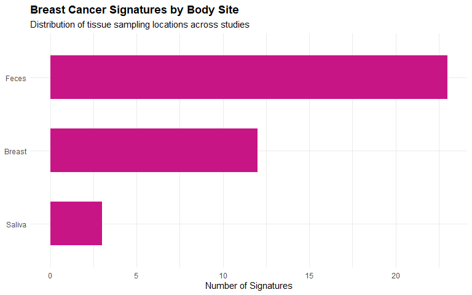

```r
breast_dat %>%
  count(`Body site`, sort = TRUE) %>%
  ggplot(aes(x = reorder(`Body site`, n), y = n)) +
  geom_col(fill = "#C71585", width = 0.6) +
  coord_flip() +
  labs(
    title = "Breast Cancer Signatures by Body Site",
    subtitle = "Distribution of tissue sampling locations across studies",
    x = NULL, y = "Number of Signatures"
  ) +
  theme_minimal(base_size = 11) +
  theme(plot.title = element_text(face = "bold"))
```

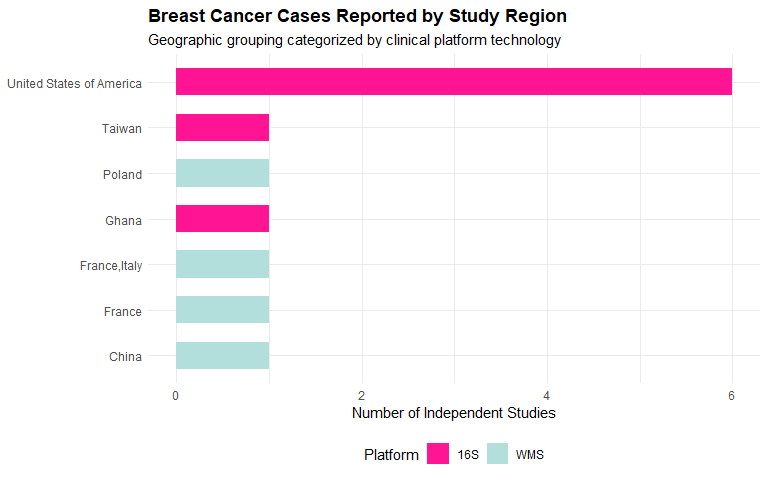

```r
breast_dat %>%
  distinct(PMID, `Location of subjects`, `Sequencing type`) %>%
  count(`Location of subjects`, `Sequencing type`) %>%
  filter(!is.na(`Location of subjects`)) %>%
  ggplot(aes(x = reorder(`Location of subjects`, n), y = n, fill = `Sequencing type`)) +
  geom_col(width = 0.6) +
  scale_fill_manual(values = c("16S" = "#FF1493", "WMS" = "#B2DFDB")) +
  coord_flip() +
  labs(
    title = "Breast Cancer Cases Reported by Study Region",
    subtitle = "Geographic grouping categorized by clinical platform technology",
    x = NULL, y = "Number of Independent Studies", fill = "Platform"
  ) +
  theme_minimal(base_size = 11) +
  theme(
    plot.title = element_text(face = "bold"),
    legend.position = "bottom"
  )
```

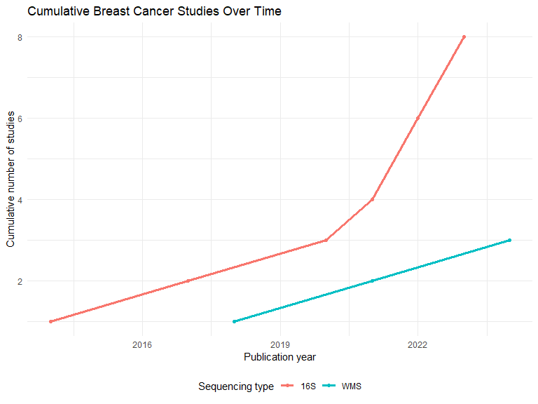

```r
breast_dat %>%
  distinct(PMID, Year, `Sequencing type`) %>%
  filter(!is.na(Year)) %>%
  count(Year, `Sequencing type`) %>%
  group_by(`Sequencing type`) %>%
  arrange(Year) %>%
  mutate(cumulative_n = cumsum(n)) %>%
  ungroup() %>%
  ggplot(aes(x = Year, y = cumulative_n, color = `Sequencing type`)) +
  geom_line(linewidth = 1.2) +
  geom_point() +
  labs(
    title = "Cumulative Breast Cancer Studies Over Time",
    x = "Publication year", y = "Cumulative number of studies", color = "Sequencing type"
  ) +
  theme_minimal(base_size = 11) +
  theme(legend.position = "bottom")
```

# Taxonomic Summary

```r
taxa.table <- createTaxonTable(breast_dat)
knitr::kable(head(taxa.table, 20))
```

[output not shown]

# Split by Sequencing Type

```r
breast.wms <- breast_dat %>% filter(`Sequencing type` == "WMS")
breast.16s <- breast_dat %>% filter(`Sequencing type` == "16S")

cat("WMS  - signatures:", nrow(breast.wms), "| studies:", n_distinct(breast.wms$PMID), "\n")
```

```
## WMS  - signatures: 9 | studies: 3
```

```r
cat("16S  - signatures:", nrow(breast.16s), "| studies:", n_distinct(breast.16s$PMID), "\n")
```

```
## 16S  - signatures: 29 | studies: 8
```

# Long-Format Taxon Table Setup

```r
sigs.breast <- bugsigdbr::getSignatures(breast_dat, tax.id.type = "taxname")

# Also pull a broader copy for cross-condition reference background mapping
sigs.all <- bugsigdbr::getSignatures(dat, tax.id.type = "taxname")

taxon.long <- purrr::map_dfr(seq_along(sigs.all), function(i) {
  taxa <- sigs.all[[i]]
  if (length(taxa) == 0) return(NULL)
  tibble::tibble(sig_id = i, taxon = taxa)
}) %>%
  left_join(
    dat %>%
      mutate(sig_id = row_number()) %>%
      select(sig_id, PMID, Condition, `Sequencing type`, `Abundance in Group 1`),
    by = "sig_id"
  ) %>%
  rename(direction = `Abundance in Group 1`)

cat("Long-format table successfully built with", nrow(taxon.long), "rows.\n")
```

```
## Long-format table successfully built with 43411 rows.
```

```r
knitr::kable(head(taxon.long), caption = "Preview of the Structured Long-Format Taxon Table")
```

Preview of the Structured Long-Format Taxon Table

| sig_id | taxon | PMID | Condition | Sequencing type | direction |
| --- | --- | --- | --- | --- | --- |
| 1 | Bacilli | 28038683 | Colorectal adenoma | 16S | increased |
| 1 | Gammaproteobacteria | 28038683 | Colorectal adenoma | 16S | increased |
| 1 | Actinomyces | 28038683 | Colorectal adenoma | 16S | increased |
| 1 | Corynebacterium | 28038683 | Colorectal adenoma | 16S | increased |
| 1 | Streptococcus | 28038683 | Colorectal adenoma | 16S | increased |
| 1 | Peptoniphilus | 28038683 | Colorectal adenoma | 16S | increased |

# Taxon Frequency Across Studies

```r
taxon.freq <- taxon.long %>%
  filter(Condition %in% breast_terms) %>%
  distinct(PMID, taxon, direction) %>%
  count(taxon, direction, name = "n_studies") %>%
  group_by(taxon) %>%
  mutate(total_studies = sum(n_studies)) %>%
  ungroup() %>%
  arrange(desc(total_studies))

n_distinct(taxon.freq$taxon)
```

```
## [1] 279
```

```r
taxon.freq %>%
  distinct(taxon, total_studies) %>%
  slice_max(total_studies, n = 15) %>%
  knitr::kable()
```

| taxon | total_studies |
| --- | --- |
| Bacillota | 5 |
| Eubacterium | 5 |
| Fusobacterium | 5 |
| Porphyromonas | 5 |
| Alistipes | 4 |
| Bacteroidota | 4 |
| Gemella | 4 |
| Leptotrichia | 4 |
| Parvimonas | 4 |
| Peptostreptococcus | 4 |
| Prevotellaceae | 4 |
| Solobacterium | 4 |
| Streptococcus | 4 |
| Subdoligranulum | 4 |
| Actinomyces | 3 |
| Actinomycetota | 3 |
| Alloprevotella | 3 |
| Anaerococcus | 3 |
| Bacillus | 3 |
| Bacteroidales | 3 |
| Bacteroidia | 3 |
| Campylobacter | 3 |
| Candidatus Saccharimonas | 3 |
| Corynebacterium | 3 |
| Cyanobacteriota | 3 |
| Eubacterium sp. | 3 |
| Granulicatella | 3 |
| Haemophilus | 3 |
| Lachnospiraceae bacterium NK4A136 | 3 |
| Lactobacillus | 3 |
| Oscillospiraceae | 3 |
| Prevotella | 3 |
| Prevotella sp. | 3 |
| Pseudomonadota | 3 |
| Rothia | 3 |
| [Ruminococcus] torques | 3 |

# Core Consensus Signature

```r
concordance <- taxon.long %>%
  filter(Condition %in% breast_terms) %>%
  distinct(PMID, taxon, direction) %>%
  group_by(taxon) %>%
  summarise(
    n_studies       = n_distinct(PMID),
    n_increased     = sum(direction == "increased"),
    n_decreased     = sum(direction == "decreased"),
    concordance_pct = round(max(n_increased, n_decreased) / n_studies * 100, 1),
    majority_dir    = if_else(n_increased >= n_decreased, "increased", "decreased"),
    .groups = "drop"
  ) %>%
  arrange(desc(n_studies), desc(concordance_pct))

# Standard threshold (matching the General analysis): >=3 studies, >=75% concordance.
# If this returns very few/zero rows given the smaller sample size here, consider
# loosening to >=2 studies / >=70% concordance, as was done for Cervical Cancer -
# and note that deviation explicitly in the Discussion section if you do.
core.sig <- concordance %>%
  filter(n_studies >= 3, concordance_pct >= 75) %>%
  arrange(majority_dir, desc(n_studies))

nrow(core.sig)
```

```
## [1] 3
```

```r
knitr::kable(core.sig)
```

| taxon | n_studies | n_increased | n_decreased | concordance_pct | majority_dir |
| --- | --- | --- | --- | --- | --- |
| Lactobacillus | 3 | 0 | 3 | 100 | decreased |
| Oscillospiraceae | 3 | 3 | 0 | 100 | increased |
| Prevotellaceae | 3 | 3 | 1 | 100 | increased |

# Core Signature Visualisation

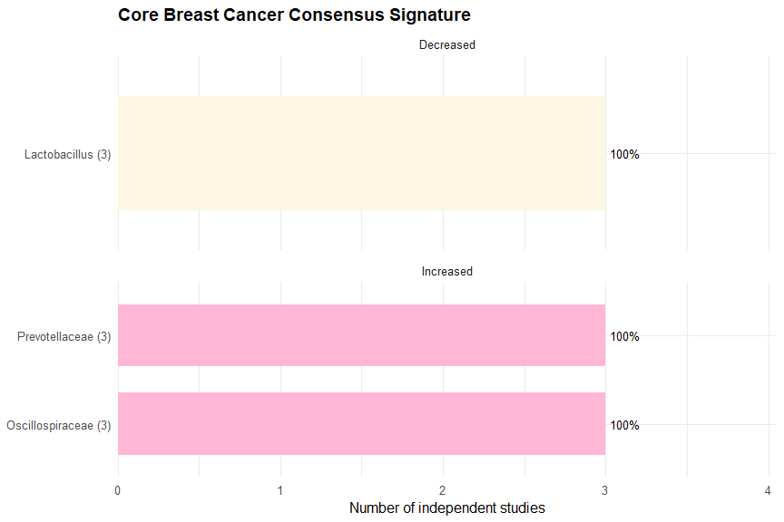

```r
if (nrow(core.sig) > 0) {
  core.sig %>%
    group_by(majority_dir) %>%
    slice_max(n_studies, n = 15, with_ties = FALSE) %>%
    ungroup() %>%
    mutate(
      direction_label = if_else(majority_dir == "increased", "Increased", "Decreased"),
      taxon_label = paste0(str_wrap(taxon, width = 28), " (", n_studies, ")")
    ) %>%
    ggplot(aes(x = reorder(taxon_label, n_studies), y = n_studies, fill = direction_label)) +
    geom_col(width = 0.7) +
    geom_text(aes(label = paste0(concordance_pct, "%")), hjust = -0.15, size = 3.3) +
    coord_flip(clip = "off") +
    facet_wrap(~direction_label, scales = "free_y", ncol = 1) +
    scale_fill_manual(values = c("Increased" = "#FFB7D5", "Decreased" = "#FDF6E2")) +
    scale_y_continuous(expand = expansion(mult = c(0, 0.35))) +
    labs(
      title = "Core Breast Cancer Consensus Signature",
      x = NULL, y = "Number of independent studies", fill = NULL
    ) +
    theme_minimal(base_size = 12) +
    theme(legend.position = "none", plot.title = element_text(face = "bold"))
} else {
  cat("No taxa met the core-signature threshold at this sample size.")
}
```

# WMS vs 16S Concordance

```r
dir.by.platform <- taxon.long %>%
  filter(Condition %in% breast_terms) %>%
  filter(`Sequencing type` %in% c("WMS", "16S")) %>%
  distinct(PMID, taxon, direction, `Sequencing type`) %>%
  count(taxon, `Sequencing type`, direction, name = "n_studies") %>%
  group_by(taxon, `Sequencing type`) %>%
  slice_max(n_studies, n = 1, with_ties = FALSE) %>%
  ungroup() %>%
  select(taxon, `Sequencing type`, majority_dir = direction)

platform.compare <- dir.by.platform %>%
  pivot_wider(names_from = `Sequencing type`, values_from = majority_dir) %>%
  filter(!is.na(WMS), !is.na(`16S`)) %>%
  rename(dir_WMS = WMS, dir_16S = `16S`) %>%
  mutate(agree = dir_WMS == dir_16S)

nrow(platform.compare)
```

```
## [1] 26
```

```r
if (nrow(platform.compare) > 0) {
  sum(platform.compare$agree)
  round(100 * mean(platform.compare$agree), 1)
  knitr::kable(platform.compare)
} else {
  cat("No taxa reported by both WMS and 16S in this breast-cancer dataset.")
}
```

| taxon | dir_16S | dir_WMS | agree |
| --- | --- | --- | --- |
| Adlercreutzia | decreased | increased | FALSE |
| Alistipes | decreased | decreased | TRUE |
| Alloprevotella | decreased | increased | FALSE |
| Bacilli | decreased | decreased | TRUE |
| Bacillota | increased | increased | TRUE |
| Bacteroidales | decreased | increased | FALSE |
| Bacteroidia | decreased | increased | FALSE |
| Bacteroidota | decreased | increased | FALSE |
| Candidatus Saccharimonas | decreased | increased | FALSE |
| Clostridia | increased | increased | TRUE |
| Coprococcus | decreased | increased | FALSE |
| Corynebacterium | increased | increased | TRUE |
| Cyanobacteriota | increased | increased | TRUE |
| Eubacteriales | decreased | increased | FALSE |
| Faecalibacterium | decreased | increased | FALSE |
| Fusobacterium | increased | decreased | FALSE |
| Gammaproteobacteria | decreased | decreased | TRUE |
| Haemophilus | decreased | increased | FALSE |
| Lactobacillaceae | decreased | decreased | TRUE |
| Lactobacillales | decreased | decreased | TRUE |
| Lactobacillus | decreased | decreased | TRUE |
| Oscillospira | decreased | increased | FALSE |
| Oscillospiraceae | increased | increased | TRUE |
| Prevotella | increased | increased | TRUE |
| Prevotellaceae | decreased | increased | FALSE |
| Thomasclavelia | decreased | decreased | TRUE |

# Taxon Enrichment Analysis

```r
n.universe <- n_distinct(taxon.long %>% filter(Condition %in% breast_terms) %>% pull(taxon))
n.sigs     <- length(sigs.breast)

enrichment.df <- taxon.freq %>%
  distinct(taxon, total_studies) %>%
  mutate(
    observed         = total_studies,
    expected         = n.sigs / n.universe,
    enrichment_ratio = observed / expected,
    log2_enrichment  = log2(enrichment_ratio),
    p_value = purrr::map_dbl(observed, ~ binom.test(
      x = .x, n = n.sigs, p = 1 / n.universe, alternative = "greater"
    )$p.value),
    p_adj = p.adjust(p_value, method = "BH")
  ) %>%
  arrange(p_adj, desc(log2_enrichment))

sum(enrichment.df$p_adj < 0.05)
```

```
## [1] 89
```

```r
knitr::kable(head(enrichment.df, 15))
```

| taxon | total_studies | observed | expected | enrichment_ratio | log2_enrichment | p_value | p_adj |
| --- | --- | --- | --- | --- | --- | --- | --- |
| Bacillota | 5 | 5 | 0.1290323 | 38.75 | 5.276124 | 0.0000002 | 0.0000142 |
| Eubacterium | 5 | 5 | 0.1290323 | 38.75 | 5.276124 | 0.0000002 | 0.0000142 |
| Fusobacterium | 5 | 5 | 0.1290323 | 38.75 | 5.276124 | 0.0000002 | 0.0000142 |
| Porphyromonas | 5 | 5 | 0.1290323 | 38.75 | 5.276124 | 0.0000002 | 0.0000142 |
| Alistipes | 4 | 4 | 0.1290323 | 31.00 | 4.954196 | 0.0000089 | 0.0001768 |
| Bacteroidota | 4 | 4 | 0.1290323 | 31.00 | 4.954196 | 0.0000089 | 0.0001768 |
| Gemella | 4 | 4 | 0.1290323 | 31.00 | 4.954196 | 0.0000089 | 0.0001768 |
| Leptotrichia | 4 | 4 | 0.1290323 | 31.00 | 4.954196 | 0.0000089 | 0.0001768 |
| Parvimonas | 4 | 4 | 0.1290323 | 31.00 | 4.954196 | 0.0000089 | 0.0001768 |
| Peptostreptococcus | 4 | 4 | 0.1290323 | 31.00 | 4.954196 | 0.0000089 | 0.0001768 |
| Prevotellaceae | 4 | 4 | 0.1290323 | 31.00 | 4.954196 | 0.0000089 | 0.0001768 |
| Solobacterium | 4 | 4 | 0.1290323 | 31.00 | 4.954196 | 0.0000089 | 0.0001768 |
| Streptococcus | 4 | 4 | 0.1290323 | 31.00 | 4.954196 | 0.0000089 | 0.0001768 |
| Subdoligranulum | 4 | 4 | 0.1290323 | 31.00 | 4.954196 | 0.0000089 | 0.0001768 |
| Actinomyces | 3 | 3 | 0.1290323 | 23.25 | 4.539159 | 0.0003009 | 0.0023320 |

# Monte Carlo Critical N

```r
siglengths <- lengths(breast_dat$`MetaPhlAn taxon names`)

criticalN <- getCriticalN(
  relevant.sigs = breast_dat$`MetaPhlAn taxon names`,
  siglengths = siglengths
)

criticalN
```

[output not shown]

[output cut: 46 more lines]

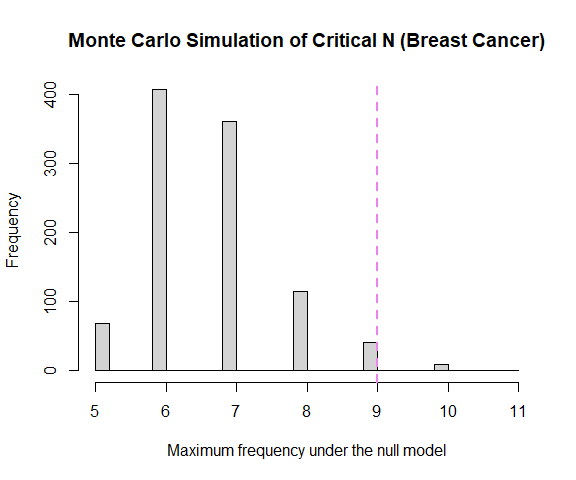

```r
hist(
  criticalN$simulated_values,
  breaks = 30,
  main = "Monte Carlo Simulation of Critical N (Breast Cancer)",
  xlab = "Maximum frequency under the null model"
)

abline(
  v = criticalN$critical_n,
  col = "violet",
  lwd = 2,
  lty = 2
)
```

# Cross-Condition Taxa Overlap Analysis

```r
breast_taxa <- taxon.long %>%
  filter(Condition %in% breast_terms) %>%
  distinct(taxon) %>%
  pull(taxon)

shared_taxa_counts <- taxon.long %>%
  filter(taxon %in% breast_taxa) %>%
  group_by(taxon) %>%
  summarise(
    total_womens_health_studies = n_distinct(PMID),
    distinct_conditions_linked = n_distinct(Condition),
    top_other_conditions = paste(
      head(setdiff(unique(Condition), breast_terms), 3),
      collapse = ", "
    ),
    .groups = "drop"
  ) %>%
  arrange(desc(distinct_conditions_linked))

shared_taxa_counts %>%
  slice_max(distinct_conditions_linked, n = 20, with_ties = FALSE) %>%
  knitr::kable(
    caption = "Top Breast-Cancer-Associated Taxa and Their Links to Other Women's Health Conditions",
    col.names = c("Taxon Name", "Total WH Studies", "Total Distinct Conditions", "Other Conditions it Often Appears In")
  )
```

| Taxon Name | Total WH Studies | Total Distinct Conditions | Other Conditions it Often Appears In |
| --- | --- | --- | --- |
| Prevotella | 329 | 174 | Hepatitis, Chronic obstructive pulmonary disease, Halitosis |
| Streptococcus | 317 | 174 | Colorectal adenoma, Chronic obstructive pulmonary disease, Autism |
| Lactobacillus | 293 | 172 | Autism, Gestational diabetes, Anxiety disorder |
| Bacteroides | 281 | 165 | Autism, Obesity, Anxiety disorder |
| Lachnospiraceae | 276 | 153 | Colorectal cancer, Chronic obstructive pulmonary disease, Anxiety disorder |
| Faecalibacterium | 232 | 148 | Anxiety disorder, Obesity, Parkinson’s disease |
| Bacillota | 263 | 146 | Autism, Type II diabetes mellitus, Anxiety disorder |
| Veillonella | 222 | 137 | Hepatitis, Chronic obstructive pulmonary disease, Chronic fatigue syndrome |
| Pseudomonadota | 213 | 126 | Autism, Gestational diabetes, Schizophrenia |
| Blautia | 195 | 125 | Obesity, Schizophrenia, Alzheimer’s disease |
| Oscillospiraceae | 210 | 124 | Anxiety disorder, Obesity, Alzheimer’s disease |
| Ruminococcus | 185 | 124 | Hepatitis, Autism, Obesity |
| Clostridium | 201 | 118 | Colorectal adenoma, Chronic obstructive pulmonary disease, Autism |
| Actinomycetota | 208 | 116 | Head and neck squamous cell carcinoma, Hepatitis, Autism |
| Fusobacterium | 196 | 116 | Colorectal cancer, Chronic obstructive pulmonary disease, Anxiety disorder |
| Enterobacteriaceae | 176 | 115 | Anxiety disorder, Schizophrenia, Unipolar depression |
| Bacteroidota | 189 | 114 | Hepatitis, Autism, Gestational diabetes |
| Eubacteriales | 176 | 112 | Halitosis, Anxiety disorder, Schizophrenia |
| Parabacteroides | 172 | 112 | Hepatitis, Autism, Anxiety disorder |
| Prevotellaceae | 162 | 109 | Obesity, Anxiety disorder, Schizophrenia |

# Shared Dysbiosis Visualisation

[figure not shown]

```r
top_shared_taxa <- shared_taxa_counts %>%
  filter(distinct_conditions_linked > 1) %>%
  slice_max(total_womens_health_studies, n = 15, with_ties = FALSE) %>%
  pull(taxon)

if (length(top_shared_taxa) > 0) {
  taxon.long %>%
    filter(taxon %in% top_shared_taxa) %>%
    mutate(Condition_Group = if_else(Condition %in% breast_terms, "Breast Cancer", Condition)) %>%
    count(taxon, Condition_Group) %>%
    ggplot(aes(x = reorder(taxon, n), y = n, fill = Condition_Group)) +
    geom_col() +
    coord_flip() +
    labs(
      title = "Breast Cancer Taxa Active in Other Conditions",
      subtitle = "Tracking where prominent breast-cancer-associated microbes show up elsewhere",
      x = NULL, y = "Total Signature Mentions", fill = "Condition Group"
    ) +
    theme_minimal(base_size = 11) +
    theme(legend.position = "right")
}
```

# Signature Similarity and Heatmap

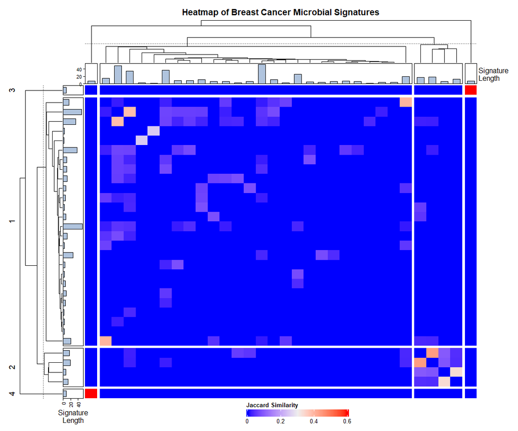

```r
allsigs <- bugsigdbr::getSignatures(breast_dat, tax.id.type = "taxname")
allsigs <- allsigs[sapply(allsigs, length) > 1]

if (length(allsigs) > 1) {
  jmat <- BugSigDBStats::calcJaccardSimilarity(allsigs)
  siglengths <- sapply(allsigs, length)

  ha <- HeatmapAnnotation(
    `Signature\nLength` = anno_barplot(siglengths, gp = gpar(fill = "#B0C4DE"), height = unit(1.2, "cm"))
  )
  hr <- rowAnnotation(
    `Signature\nLength` = anno_barplot(siglengths, gp = gpar(fill = "#B0C4DE"), width = unit(1.2, "cm"))
  )

  hm <- Heatmap(
    jmat,
    top_annotation = ha,
    left_annotation = hr,
    show_row_names = FALSE,
    show_column_names = FALSE,

    row_km = 4,
    column_km = 4,
    row_gap = unit(1.5, "mm"),
    column_gap = unit(1.5, "mm"),

    row_dend_width = unit(2.5, "cm"),
    column_dend_height = unit(2.5, "cm"),

    column_title = "Heatmap of Breast Cancer Microbial Signatures",
    column_title_gp = gpar(fontsize = 14, fontface = "bold"),
    heatmap_legend_param = list(
      title = "Jaccard Similarity",
      direction = "horizontal",
      legend_width = unit(6, "cm")
    )
  )

  draw(hm, heatmap_legend_side = "bottom", padding = unit(c(5, 5, 5, 5), "mm"))

  png(filename = "BreastCancer_heatmap.png", width = 12, height = 10, units = "in", res = 300)
  draw(hm, heatmap_legend_side = "bottom", padding = unit(c(5, 5, 5, 5), "mm"))
  dev.off()
}
```

# Dendrogram

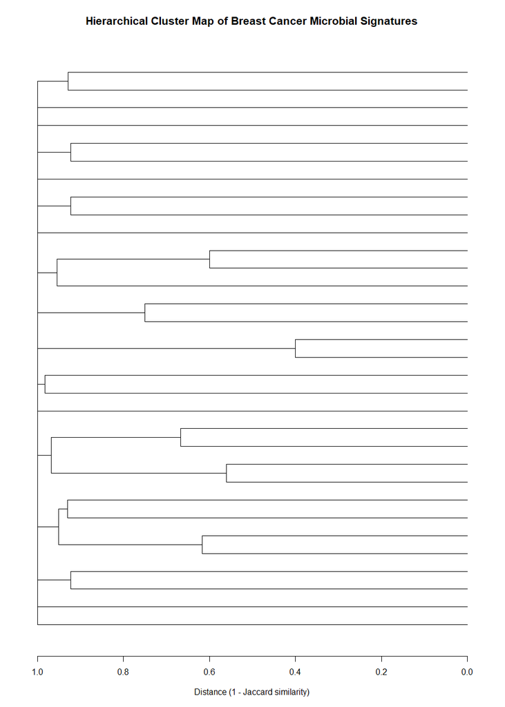

```r
if (exists("jmat") && nrow(jmat) > 1) {
  hc <- hclust(as.dist(1 - jmat))
  dend <- as.dendrogram(hc)

  par(mar = c(5, 2, 4, 2))

  plot(
    dend,
    horiz = TRUE,
    leaflab = "none",
    main = "Hierarchical Cluster Map of Breast Cancer Microbial Signatures",
    xlab = "Distance (1 - Jaccard similarity)",
    cex.main = 1.3,
    lwd = 0.8
  )
}
```